# Tarea 3. Procesos puntuales (point patterns).

Author

Agatha Del Olmo Tirado

Published

April 13, 2025

## 1. Introducción

En este trabajo se analiza la distribución de las ciudades pequeñas en la provincia de Valencia, con el objetivo de estudiar si dicha distribución sigue un patrón espacial aleatorio o no. Para ello, se realiza un análisis de aleatoriedad espacial completa (CSR - Complete Spatial Randomness). En caso de que se detecte que no se distribuyen de manera completamente aleatoria, se buscará estudiar si presentan un patrón de agregación.

Este tipo de análisis es especialmente interesante para entender cómo se organizan los asentamientos pequeños en el territorio valenciano, y puede ser de utilidad para la toma de decisiones en cuanto a planificación territorial, construcción de infraestructuras o el diseño de políticas públicas.

Para empezar, se instalan y cargan todos los paquetes necesarios para trabajar con datos espaciales, visualizarlos y analizarlos estadísticamente:

```r
libs <- c("tidyverse", "sf", "mapSpain", "osmdata", "ggspatial", "dplyr", "readr", "readxl",
          "tidyverse", "sf", "ggplot2", "RColorBrewer", "tidygeocoder", "stringi", "leaflet",
          "plotly", "dbscan", "leaflet.extras", "spatstat", "sp", "splancs")

installed_libs <- libs %in% rownames(installed.packages())

if (any(installed_libs == F)) {install.packages(libs[!installed_libs])}
invisible(lapply(libs, library, character.only = T))

rm(libs, installed_libs)
```

También se fuerza la detección de conexión a Internet, útil en algunos entornos de red donde esto puede fallar por configuración de proxy:

```r
curl::has_internet()
```

```
[1] TRUE
```

```r
assign("has_internet_via_proxy", TRUE, environment(curl::has_internet))
curl::has_internet()
```

```
[1] TRUE
```

## 2. Carga de los datos

Para este estudio se parte de datos obtenidos de OpenStreetMap (OSM), una fuente colaborativa y abierta de datos geográficos. En concreto, se buscan los lugares clasificados como `town`, que, según la documentación de OSM, generalmente corresponden a ciudades pequeñas, entendidas como núcleos urbanos con más servicios que los pueblos (village), pero menos que las ciudades grandes (city). Aunque esta clasificación puede variar según el país o incluso el voluntario que la asigna, en 2019, el 95% de los lugares etiquetados como town tenía una población estimada entre 1.000 y 70.000 habitantes.

**OSM**

Cabe mencionar que al ser OSM una fuente de datos abierta y colaborativa de forma voluntaria, es fácil que los datos sean algo incompletos o que su clasificación no siga un criterio muy claro.

Se define el área de estudio utilizando el paquete mapSpain, seleccionando específicamente la provincia de Valencia, y se transforma al sistema de coordenadas EPSG 4326, que es el que utiliza OSM (WGS84):

```r
prov <- mapSpain::esp_get_prov()
valencia_prov <- prov[prov$ine.prov.name == "Valencia/València", ]
cat <- st_transform(valencia_prov, 4326)
bbox_cat <- osmdata::getbb("València / Valencia")
```

A continuación, Usando este área de interés, se realiza una consulta sobre la zona definida para extraer los lugares etiquetados como `town` en OpenStreetMap. Y a partir de los datos obtenidos, se extraen los puntos y polígonos correspondientes, y de los polígonos, calculamos los centroides, los cuales representan los puntos geográficos centrales de estos.

```r
town <-osmdata::opq(bbox = bbox_cat) %>%
  osmdata::add_osm_feature(key = "place", value = "town") %>%
  osmdata::osmdata_sf()

town_points <- town$osm_points
town_points <- st_intersection(town_points, cat)

town_cen <- st_centroid(town$osm_polygons)
town_cen <- st_intersection(town_cen, cat)
```

Luego, se utiliza la función `st_write()` para guardar estas capas en un archivo GeoPackage llamado “town_points.gpkg” y “town_cen.gpkg”, especificando las capas y el formato correspondiente. De la misma forma, se usa la función `st_read()` para asegurar la reproducibilidad del archivo desde cualquier directorio.

```r
#st_write(town_points, "town_points.gpkg", layer = "osm_points", driver = "GPKG")
town_points <- st_read("town_points.gpkg", layer = "osm_points")
#st_write(town_cen, "town_cen.gpkg", layer = "osm_centroids", driver = "GPKG")
town_cen <- st_read("town_cen.gpkg", layer = "osm_centroids")
```

## 3. Limpieza de los datos

Analizando los objetos, por un lado, se descubre que únicamente hay un centroide, el que representa a Pedralba. Se comprueba que este no se encuentra en el objeto de puntos ignornado los NA.

```r
nrow(town_cen)
```

```
[1] 1
```

```r
town_cen$name
```

```
[1] "Pedralba"
```

```r
sum(!is.na(town_points$name) & town_points$name ==town_cen$name[1])
```

```
[1] 0
```

Se confirma que no se duplica la ciudad Pedralba, de forma que no se realiza ninguna modificación a `town_cen`.

Por otro lado, se estudia cuántos valores NA (Not Available) hay en la variable del nombre de las ciudades `name` en `town_points`.

```r
sum(is.na(town_points$name))
```

```
[1] 378
```

Se detecta que hay 378 NA, lo cual se puede explicar porque la mayoría conforman polígonos, de forma que varios puntos están representando el mismo lugar.

Para continuar correctamente primero se analiza el mapa interactivo para observar los problemas mejor:

```r
leaflet() %>%
  addTiles() %>%  # Usa tiles por defecto de OpenStreetMap
  addCircleMarkers(data = town_points,
                   color = "orange",
                   radius = 8,
                   stroke = FALSE,
                   fillOpacity = 0.7,
                   label = ~name)
```

[interactive chart not shown]

Se comprueba que Pedralba tiene puntos pero ninguno está identificado con su nombre en `name`. De la misma forma, Rafelbunyol tiene puntos que conforman el polígono, pero solo el central tiene etiquetado el nombre en `name`. Por lo tanto, se concluye que una forma de recuperar solo un punto por ciudad, se seleccionan aquellos puntos que sí tienen nombre asociado.

```r
town_points <- town_points[!is.na(town_points$name),]
```

Finalmente, se combinan los puntos con nombre de las ciudades pequeñas y el centroide de Pedralba en un solo conjunto de datos, seleccionando las columnas de geometría y nombre para cada uno. Este conjunto se crea utilizando la función `rbind()` y se denomina `todos_town`, que ahora incluye todos los puntos representativos de las ciudades. Para visualizar la distribución espacial de estas ciudades en la provincia de Valencia, se genera un mapa interactivo con leaflet, donde se añaden marcadores circulares de color naranja en las ubicaciones de las ciudades. Al pasar el cursor sobre un marcador, se muestra el nombre de la ciudad, permitiendo una exploración visual clara de la distribución de las ciudades pequeñas y sus concentraciones geográficas.

```r
town_cen <- town_cen %>%
  select(geom, name)

town_points <- town_points %>%
  select(geom, name)

todos_town <- rbind(town_points, town_cen)

leaflet() %>%
  addTiles() %>%  # Usa tiles por defecto de OpenStreetMap
  addCircleMarkers(data = todos_town,
                   color = "orange",
                   radius = 8,
                   stroke = FALSE,
                   fillOpacity = 0.7,
                   label = ~name)
```

[interactive chart not shown]

## 4. Análisis de Complete Spatial Randomness (CSR)

En el contexto de este trabajo, CSR (Complete Spatial Randomness o Aleatoriedad Espacial Completa) se refiere a la distribución aleatoria de las ciudades pequeñas en la provincia de Valencia, es decir, a un patrón en el que las ciudades estarían dispuestas sin ninguna regularidad o estructura, sin zonas de mayor concentración o dispersión. Si la distribución no responde a CSR, y no es de tipo uniforme, se sugiere la existencia de un patrón de agregación, lo que indica que las ciudades pequeñas tienden a concentrarse en determinadas áreas, como la costa o cerca de la capital, Valencia.

Para ello, es necesario transformar las geometrías al sistema métrico (EPSG 3857), obtener las coordenadas y generar el objeto ppp necesario para trabajar con spatstat.

```r
todos_town_m <- st_transform(todos_town, crs = 3857)
cat_m <- st_transform(cat, crs = 3857)

coords <- st_coordinates(todos_town_m)

window_owin <- as.owin(cat_m)

town_ppp <- ppp(x = coords[, 1], y = coords[, 2], window = window_owin)
```

En primer lugar, se visualiza la densidad de las ciudades pequeñas en el espacio mediante un gráfico. El resultado de esta visualización muestra la distribución de las ciudades a lo largo del área de estudio, permitiendo observar posibles concentraciones o dispersión de las ciudades dentro de la provincia de Valencia. Un patrón de alta densidad en ciertas áreas y baja densidad en otras puede indicar la presencia de agrupamientos o zonas deshabitadas.

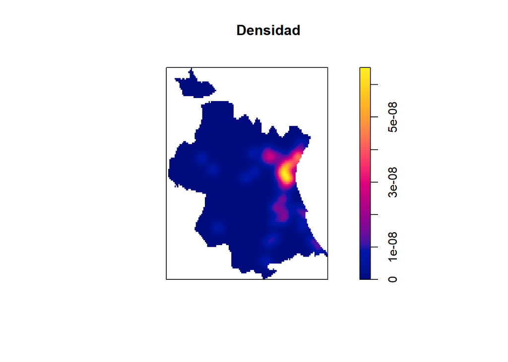

```r
den1 <- density(as(town_ppp,"ppp"), sigma = bw.diggle)
plot(den1, main = "Densidad")
```

Se observa una clara concentración en la zona este. Por lo tanto, se realiza un análisis visual mediante un conteo por cuadrantes, dividiendo el área de estudio (la provincia de Valencia) en una cuadrícula de 3x3. El objetivo de esta técnica es tener una primera idea de la distribución espacial de las ciudades pequeñas viendo cuál es el número de ciudades en cada zona.

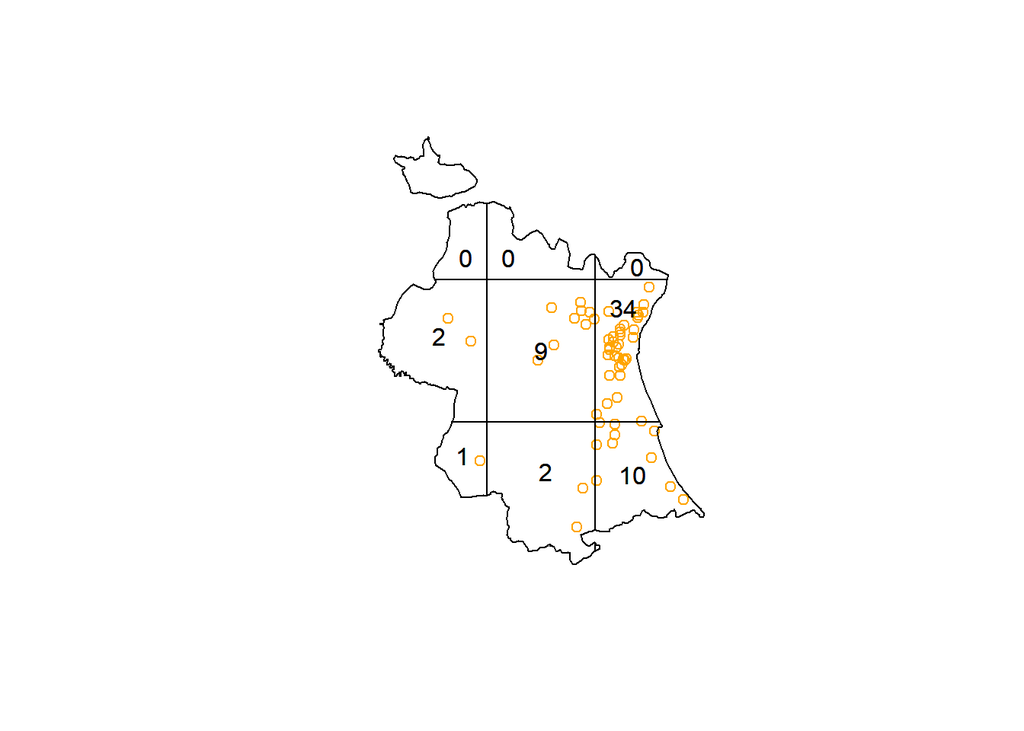

```r
q1 = quadratcount(town_ppp, nx=3, ny=3)
{
  plot(q1, main = "") # Añado este para que el recuadro esté bien
  plot(todos_town_m$geom, col = 'orange', add = TRUE)
  plot(q1, main = "", add= TRUE) # Ahora añado este porque los puntos naranjas tapan los números
}
```

Como se puede observar, hay un claro patrón de concentración en el cuadrante central derecho, donde se encuentra el valor más alto con 34 localidades, seguido por el cuadrante inferior derecho con 10, y el central con 9. En cambio, hay cuadrantes como el superior izquierdo, el superior central y el superior derecho que no contienen ninguna ciudad clasificada como town.

Ignorando el hecho de que cada cuadrante tiene un tamaño muy desigual, estos resultados permiten adelantar que la distribución no parece aleatoria, ya que existe una alta densidad de puntos en zonas muy concretas, mientras que otras áreas están completamente vacías.

Esto puede estar relacionado con la geografía física de la provincia (por ejemplo, la presencia del sistema montañoso al oeste y la costa al este), y desde el punto de vista estadístico, este comportamiento sugiere un posible patrón de agregación.

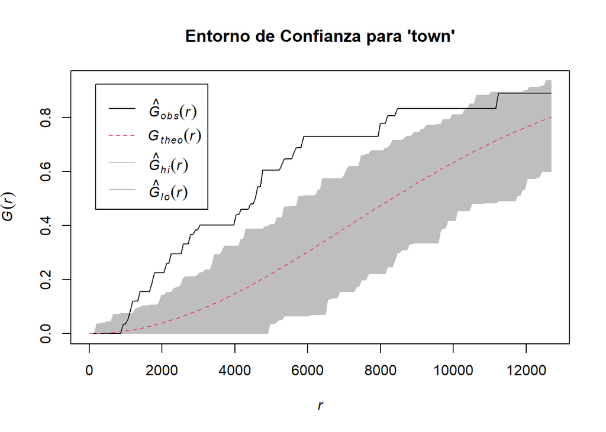

```r
env_town <- envelope(town_ppp, fun=Gest, nsim=100, nrank=2, verbose = F)
plot(env_town, main="Entorno de Confianza para 'town'")
```

Para confirmar esta hipótesis, se calcula el envelope de la función G, que permite comparar la función de distribución empírica de las distancias entre puntos con lo que se esperaría bajo una hipótesis de aleatoriedad espacial completa (CSR).

El envelope se genera con 100 simulaciones aleatorias, y los resultados muestran que la curva observada (línea negra) se sitúa por encima del límite superior del envelope teórico (zonas grises) en los primeros tramos.

Esto indica que las distancias más pequeñas entre localidades son más frecuentes de lo que sería esperable si estuvieran distribuidas aleatoriamente, lo que confirma la existencia de agrupamientos o clusters. Este tipo de resultado es característico de una distribución agregada, donde las entidades tienden a situarse más cerca unas de otras de lo que ocurriría bajo una distribución aleatoria uniforme.

Para profundizar en el análisis de la aleatoriedad espacial, se calcula la función K de Ripley, junto con su transformación L, que permite una interpretación más directa al representar distancias reales entre puntos.

Estas funciones comparan la cantidad de puntos encontrados dentro de una distancia r respecto a un punto de referencia, y se comparan con lo que se esperaría bajo un proceso de Poisson espacial (CSR: Complete Spatial Randomness).

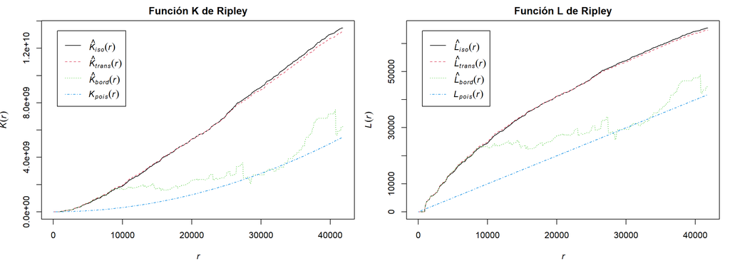

```r
par(mfrow = c(1, 2), mar = c(4, 4, 2, 1))

K <- Kest(town_ppp)
plot(K, main = "Función K de Ripley")

L <- Lest(town_ppp)
plot(L, main = "Función L de Ripley")
```

En estos gráficos se observa que la curva observada (línea negra y roja) se encuentra claramente por encima de la curva teórica bajo CSR $L_{pois}(r)$ y $K_{pois}(r)$, representada con una línea azul punteada. Esto ocurre de forma consistente en todo el rango de distancias analizadas, lo que indica que la cantidad de ciudades pequeñas dentro de cada radio es sistemáticamente mayor que lo que se esperaría bajo aleatoriedad.

Esto confirma lo ya anticipado por la función G: existe agregación espacial significativa en la distribución de las ciudades pequeñas. En otras palabras, estas no están repartidas de forma homogénea por la provincia de Valencia, sino que tienden a concentrarse en determinadas zonas.

Existen diversos factores y variables que podrían explicar la presencia de clústeres o la distribución uniforme de estos eventos. Entre los factores geográficos, se destacan la proximidad a la costa, la presencia de sistemas montañosos y la cercanía a la capital, Valencia. Las ciudades tienden a concentrarse en áreas con mejores accesos a infraestructuras clave como carreteras principales, puertos y centros de transporte, lo que facilita la conectividad y la accesibilidad. Además, los factores socioeconómicos como el desarrollo económico, la oferta de servicios y la calidad de vida pueden atraer más población a ciertas zonas, favoreciendo la formación de clústeres. También influye la historia urbana, ya que muchas ciudades pequeñas de la zona se han desarrollado históricamente cerca de puertos por su ventaja comercial.

## 5. Resultados y conclusión

Los resultados obtenidos confirman que las ciudades pequeñas en la provincia de Valencia no están distribuidas aleatoriamente. En lugar de eso, presentan un patrón de agregación, concentrándose en determinadas zonas, principalmente cerca de la capital y a lo largo de la costa. Este patrón podría estar influenciado por factores geográficos y socioeconómicos, y tiene implicaciones importantes para la planificación territorial y el diseño de políticas públicas.

En términos de planificación territorial, la identificación de clústeres en la distribución de las ciudades pequeñas puede guiar la asignación de recursos y el desarrollo de infraestructuras clave, como carreteras, transporte público o servicios básicos, priorizando las áreas con mayor concentración de población. Para la construcción de infraestructuras, las zonas con mayor densidad podrían recibir más inversiones, mejorando la accesibilidad y conectividad entre ciudades cercanas (sin, por supuesto, olvidar los pueblos y su nencesidad de conectividad).

En cuanto al diseño de políticas públicas, los patrones de distribución pueden ayudar a orientar políticas de desarrollo regional más equitativas, distribuyendo servicios y oportunidades de manera más eficiente, y promoviendo el crecimiento económico en áreas estratégicas. En general, estos patrones permiten una planificación más informada y adaptada a las necesidades del territorio.

## 6. Bibliografía

[Giménez, V. P. (n.d.). Datos espaciales y espaciotemporales.](https://www.uv.es/pegivir/DEE/index)

[Del Inglés, L. M. (n.d.). Diferencia de uso en inglés entre city y town y village. La Mansión Del Inglés.](https://www.mansioningles.com/errores-gramaticales-ingles/diferencia-uso-city-town-village)

[Gisadminbeers. (2019, September 4). Equivalencia de códigos EPSG - Gis&Beers.](https://www.gisandbeers.com/equivalencia-codigos-epsg-sistemas-referencia/)

[Coordenadas geográficas de España - Latitud y longitud. (n.d.). Geodatos.](https://www.geodatos.net/coordenadas/espana)

[OpenStreetMap Wiki. (n.d.).](https://wiki.openstreetmap.org/wiki/Main_Page)

[Google Maps. (n.d.).](https://www.google.es/maps/?hl=es)

[Coder, R. (2024, January 4). Mapas interactivos con leaflet en R. R CHARTS | Una Colección De Gráficos Hechos Con El Lenguaje De Programación R.](https://r-charts.com/es/espacial/mapas-interactivos-leaflet/)